**Chapter 8: Predation and wildlife populations**

## Objectives

This assignment reviews functional response and predation rate, which (as you know) helps us understand both the effects of predators on prey populations and effects of human hunting on game (prey) animals.

## Overview of the predator-prey system

Management of critically endangered species may pose considerable scientific and ethical dilemmas. Channel Islands are inhabited by an endemic, carnivore species, the island fox (Urocyon litteralis). These islands are also populated by introduced feral pigs (Sus scrofa). The presence of pigs (and the loss of bald eagles) enabled golden eagles (Aquila chrysaetos) to colonize the islands in early 1990’s. The eagles prey mainly on pigs and foxes are their secondary, alternative prey. Canine distemper became an issue in the late 1990s. The species was listed as endangered, and things looked bleak for island fox. Science-based conservation recommendations were badly needed, and time was short.

## Predator responses: predation rate vs kill rate

The rate of predation by a predator population is determined by two attributes of the predator’s response to changes in prey density: functional response and numerical response. The numerical response is simply how predator number changes as prey abundance changes. The functional response relates a single predator’s prey consumption rate to prey population density.

Suppose we have a long-term dataset of abundance of Island fox, the prey, on an island and the number of prey killed per eagle predator (indexed by fox teeth per eagle scat). Predation rate is the percentage of the prey population killed per unit time.

```r
fox_data       <- data.frame( years        = 1:22,
                              abundance    = round(runif(22, 20, 200), 0))
fox_data$eaten <- 0.25 * fox_data$abundance
pred_rate      <- fox_data$eaten / fox_data$abundance * 100
print(pred_rate)
```

[output not shown]

However, the predation rate in nature is rarely constant over time. The number of prey killed will be a product of both the number of predators (the predator numerical response) and how many prey each individual predator kills (the predator functional response), i.e., number of prey killed is the predator numerical response times the predator functional response. If the prey-dependent functional response that we used was: y = 2.62 N / [6.53 + N], then the functional response increases with numerical response.

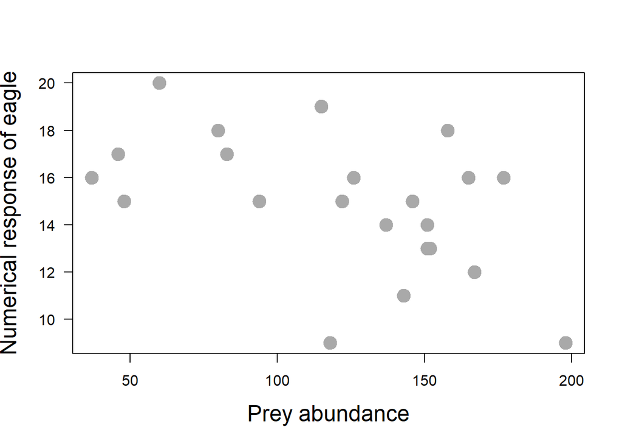

```r
eagle_data <- data.frame( years        = 1:22,
                                abundance    = round(runif(22, 8, 20), 0))
fox_data$eaten_per <- mean(fox_data$eaten) / eagle_data$abundance
kill_rate <- (2.62 * fox_data$abundance) / (6.53 + fox_data$abundance)


plot(y        = eagle_data$abundance,
     x        = fox_data$abundance,
     ylab     = "Numerical response of eagle",
     xlab     = "Prey abundance",
     cex.lab  = 1.5,
     pch      = 19,
     col      = "darkgray",
     cex      = 2,
     xaxt     = "n",
     las      = 2)
axis(1)
```

Predator population size could linearly, quadraticly or hyperbolicaly change with prey population size, or not dependent on it at all. Let’s plot the functional response, i.e., the number of foxes eaten against fox abundance. There are three types of functional response; which type do you suspect of the plot below?

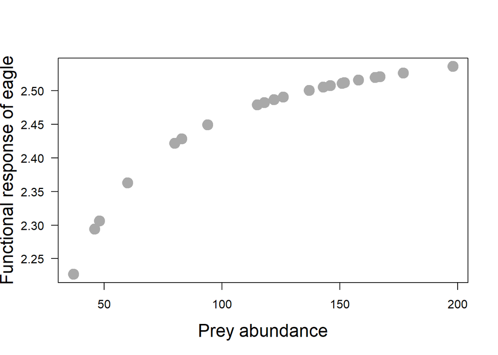

```r
plot(y        = kill_rate,
     x        = fox_data$abundance,
     ylab     = "Functional response of eagle",
     xlab     = "Prey abundance",
     cex.lab  = 1.5,
     pch      = 19,
     col      = "darkgray",
     cex      = 2,
     xaxt     = "n",
     las      = 2)
axis(1)
```

Type 2 functional response is common in nature. At low prey densities, predators take prey in an almost constant-effort fashion: if prey density doubles, then predator locates them twice as often and kills them at twice the rate. Thus, rate of predation increases almost linearly at low prey density. As prey density increases, searching for prey becomes a less important limit on the rate of predation. Prey are easy to locate, and rate of consumption is more heavily affected by handling time, the time it takes to catch, subdue, kill and eat a prey item, once prey located.

As searching becomes less important and handling becomes more important, the rate of predation shows decelerating rate of increase. (still increases, but less quickly) Eventually, search is not limiting at all, and rate of predation levels off at upper limit determined by handling time alone.

Let’s calculate predation rate and the number of prey eaten from the kill rate we calculated above.

```r
pred_rate      <- kill_rate / fox_data$abundance  * 100
n_eaten        <- kill_rate * eagle_data$abundance
print(kill_rate)
print(pred_rate)
print(n_eaten)
```

[output not shown]

**Practice:**

1. By comparing the predation rate and population size, are the changes stabilizing or destabilizing for the fox population?

```r
sample_fox <- c(min(fox_data$abundance), max(fox_data$abundance))
which(fox_data$abundance %in% sample_fox)
pred_rate[which(fox_data$abundance %in% sample_fox)]
```

[output not shown]

2. Use a function to describe the numerical response curve which changes positively with prey abundance. How does this change affect the predation rate? Find out if the predation rates are stabilizing or destabilizing the fox population.
3. Use two different functions to describe types 1 and 3 functional response curves. Then, visualize the curves for comparison.

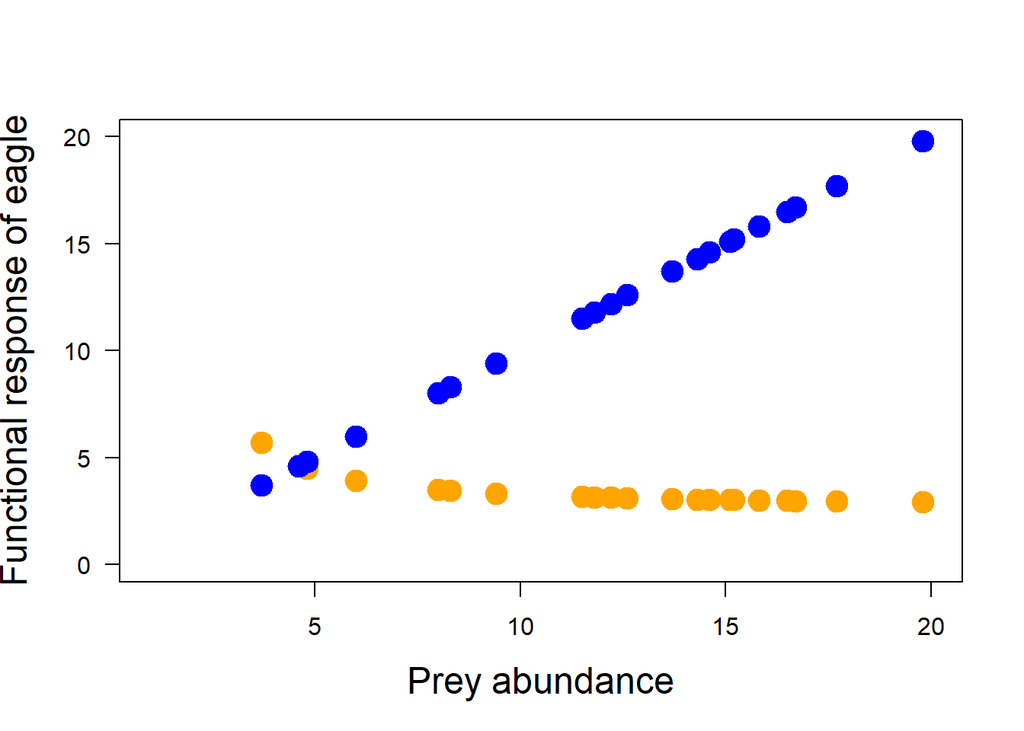

```r
fox_data$density <- fox_data$abundance / 10
kill_rate1 <- fox_data$density
kill_rate3 <- (2.62 * (fox_data$density ^ 2)) / ((-2 * fox_data$density) + (fox_data$density ^ 2))

plot(y        = kill_rate3,
     x        = fox_data$density,
     ylab     = "Functional response of eagle",
     xlab     = "Prey abundance",
     cex.lab  = 1.5,
     pch      = 19,
     col      = "orange",
     cex      = 2,
     xaxt     = "n",
     xlim     = c(1, 20),
     ylim     = c(0, 20),
     las      = 2)
axis(1)

points(x = fox_data$density, y = kill_rate1, col = "blue", pch = 19, cex = 2)
```